# Assignment 2 - Group L

Group members:

```
- Josiane Dufour 01388388
- Otto Godwin 01422474
- Zana-Ljubica Krsticevic 01423239
- Seongmin Lee 01247436
- Shuyu Zhou 01382817
```

## Question 1

```python
# libraries
#%reset
import pandas as pd
import networkx as nx
import matplotlib
import matplotlib.pyplot as plt
import numpy as np
from scipy import linalg
import pandas as pd
import networkx as nx
import numpy as np
import scipy as sp
import sys
import math
import re
import math
import random
import itertools

from gurobipy import *
from mpl_toolkits.basemap import Basemap
%matplotlib inline
```

```python
# read 'sent message' data from file
sent_df = pd.read_excel('HW2_who_talks_to_whom - sent.xlsx', index_col = 0)
sent_df = sent_df.replace('-', np.nan)
sent_df.fillna(0, inplace = True)

# read 'received message' data from file
received_df = pd.read_excel('HW2_who_talks_to_whom - received.xlsx', index_col = 0)
received_df = received_df.replace('-', np.nan)
received_df.fillna(0, inplace = True)

# convert to pandas dataframe to numpy array
sent_mat=np.array(sent_df)
received_mat=np.array(received_df)
```

```python
# Received and sent matrices should contain the same information however they do not match up.
# Therefore create new matrix cohort_mat by combining average info from both matrices.
cohort_mat = (received_mat.T + sent_mat) / 2
```

```python
# create Graph
G = nx.from_numpy_matrix(cohort_mat,create_using = nx.DiGraph())
print(len(G.nodes))
print(len(G.edges))
```

```
81
2582
```

```python
# Degree centrality
deg_cen = nx.degree_centrality(G)
```

```python
# Betweenness centrality
bet_cen = nx.betweenness_centrality(G)
```

```python
# Closeness centrality
clo_cen = nx.closeness_centrality(G)
```

```python
# PageRank centrality - eigen vector centrality computed by power iteration method
pagerank_centrality = nx.pagerank(G)
```

```python
# Clustering coefficient - calculate for underlying graph structure (undirected)
G_undir = nx.from_numpy_matrix(cohort_mat)
clustering = nx.clustering(G_undir)
```

```python
# create list of nodes from 1 to 81
node_list = np.arange(1, 82, 1)
keys_list = G.nodes()
# create dictionary with nodes as keys (0...80) and node names as values (1...81)
node_dict = dict(zip(keys_list, node_list))

# data frame of centrality measures indexed by node
centrality = pd.DataFrame(index=node_list)
centrality.index.name = 'node'
centrality['degree'] = deg_cen.values()
centrality['closeness'] = clo_cen.values()
centrality['pagerank'] = pagerank_centrality.values()
centrality['betweeness'] = bet_cen.values()
centrality['clustering'] = clustering.values()
```

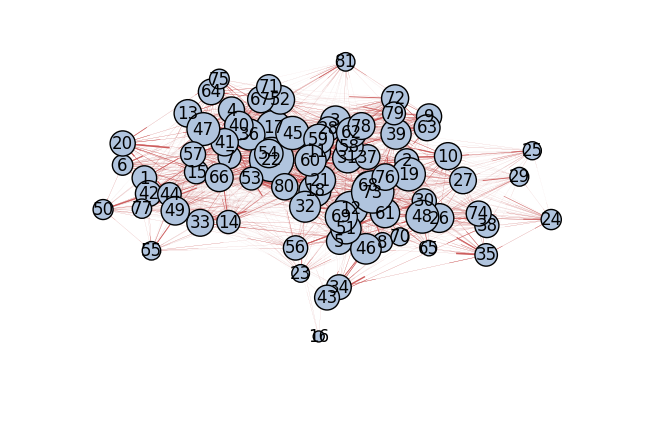

```python
# edge width drawn relative to edge weight
edge_size = [i[2]['weight']/100 for i in list(G.edges(data=True))]
# node size drawn relative to page rank of node
page_rank = [i * 30000 for i in pagerank_centrality.values()]
# draw graph
nx.draw(G, pos=nx.spring_layout(G, k=0.8, iterations = 20),labels = node_dict, node_color='lightsteelblue', node_size = page_rank, edge_color='indianred', width = edge_size, font_size=12)
```

```python
# analysis

# sort nodes by decreasing degree centrality. Node listed with actual centrality measure in open brackets.
degree_rank = centrality.sort_values(['degree'], ascending=[False])
degree_rank = degree_rank.index.map(str) + " " + "(" + degree_rank['degree'].round(decimals = 2).map(str) + ")"

# sort nodes by decreasing closeness
closeness_rank = centrality.sort_values(['closeness'], ascending=[False])
closeness_rank = closeness_rank.index.map(str) + " " + "(" + closeness_rank['closeness'].round(decimals = 2).map(str) + ")"

# sort nodes by decreasing pagerank
pagerank_rank = centrality.sort_values(['pagerank'], ascending=[False])
pagerank_rank = pagerank_rank.index.map(str) + " " + "(" + pagerank_rank['pagerank'].round(decimals = 3).map(str) + ")"

# sort nodes by decreasing betweeness
betweeness_rank = centrality.sort_values(['betweeness'], ascending=[False])
betweeness_rank = betweeness_rank.index.map(str) + " " + "(" + betweeness_rank['betweeness'].round(decimals = 3).map(str) + ")"

# sort nodes by decreasing clustering coefficient
cluster_rank = centrality.sort_values(['clustering'], ascending=[False])
cluster_rank = cluster_rank.index.map(str) + " " + "(" + cluster_rank['clustering'].round(decimals = 2).map(str) + ")"


# compile ranked nodes for each measure withactual centrality measure in open brackets
centrality_rank = pd.DataFrame()
centrality_rank['degree'] = degree_rank
centrality_rank['closeness'] = closeness_rank
centrality_rank['pagerank'] = pagerank_rank
centrality_rank['betweeness'] = betweeness_rank
centrality_rank['cluster'] = cluster_rank
# print top ten ranked nodes for each centrality measure - look for nodes that are ranked high across multiple measures
print(centrality_rank.iloc[0:10,:])
```

```
         degree  closeness    pagerank  betweeness    cluster
node
32     32 (1.4)  32 (0.77)  32 (0.016)  32 (0.034)  32 (0.43)
22     22 (1.3)  22 (0.74)  22 (0.034)  22 (0.033)  22 (0.49)
62    62 (1.18)  62 (0.71)  62 (0.015)  62 (0.015)  62 (0.56)
37    37 (1.15)   37 (0.7)   37 (0.01)  37 (0.019)  37 (0.48)
53    53 (1.12)   53 (0.7)  53 (0.009)  53 (0.019)  53 (0.45)
47    47 (1.12)   47 (0.7)  47 (0.019)   47 (0.01)  47 (0.59)
68    68 (1.12)   68 (0.7)  68 (0.013)  68 (0.016)  68 (0.49)
4      4 (1.12)    4 (0.7)   4 (0.012)   4 (0.019)   4 (0.46)
17     17 (1.1)  17 (0.69)  17 (0.021)  17 (0.016)   17 (0.6)
42     42 (1.1)  42 (0.69)  42 (0.012)  42 (0.012)  42 (0.55)
```

**Analysis**  
*Our main objective is to identify who the leaders and opinion-makers are in the cohort.*

**Step 1: *Data pre-processing & graph created***  
First, we downloaded the sent and received tables and replaced all missing values with zero (to signify no messages received or sent). We expected the transpose of the received text matrix to equal the sent matrix, given the assumption that every message recorded as sent was recorded as received by the relevant student. These matrices however did not match up simply because of inaccurate/imprecise recordings. We chose to retain information from both matrices in ‘cohort_mat’ by averaging the values of the T(received) and sent. Using ‘cohort_mat’ we created a directed graph with 81 nodes and 2582 edges.

**Step 2: *Centrality measures calculated***  
We calculated and recorded the following centrality measures for each node: degree, closeness, pagerank and betweeness. We also calculated the local clustering coefficients for the underlying undirected graph. Below is a snapshot of each node’s centrality measures.

```python
preview = centrality_rank.reset_index()
preview = preview.sort_values('node')
print(preview.iloc[0:10,:])
```

```
    node     degree  closeness    pagerank  betweeness    cluster
55     1    1 (0.7)   1 (0.61)    1 (0.01)   1 (0.005)   1 (0.57)
48     2   2 (0.73)   2 (0.61)    2 (0.01)   2 (0.004)   2 (0.68)
24     3   3 (0.95)   3 (0.66)   3 (0.015)   3 (0.012)   3 (0.61)
7      4   4 (1.12)    4 (0.7)   4 (0.012)   4 (0.019)   4 (0.46)
57     5   5 (0.68)    5 (0.6)   5 (0.011)   5 (0.005)   5 (0.65)
42     6   6 (0.78)   6 (0.62)   6 (0.007)   6 (0.005)    6 (0.6)
59     7   7 (0.65)    7 (0.6)   7 (0.009)   7 (0.003)    7 (0.7)
64     8   8 (0.58)   8 (0.58)   8 (0.007)   8 (0.004)   8 (0.53)
29     9   9 (0.88)   9 (0.64)   9 (0.011)   9 (0.008)   9 (0.61)
50    10  10 (0.73)  10 (0.61)  10 (0.013)  10 (0.006)  10 (0.59)
```

**Step 3: *Graph plotted*** To better our network topology understanding, we drew the graph with the size of the node relative to its pagerank, and the thickness of the directed edge relative to its weight. The graph is too confused to gather much information; however we can see that node 16 is unusually isolated.

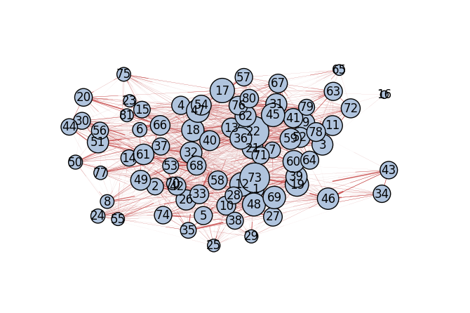

```python
nx.draw(G, pos=nx.spring_layout(G, k=0.8, iterations = 20),labels = node_dict, node_color='lightsteelblue', node_size = page_rank, edge_color='indianred', width = edge_size, font_size=12)
```

```python
print(centrality_rank.iloc[0:10,:])
```

```
         degree  closeness    pagerank  betweeness    cluster
node
32     32 (1.4)  32 (0.77)  32 (0.016)  32 (0.034)  32 (0.43)
22     22 (1.3)  22 (0.74)  22 (0.034)  22 (0.033)  22 (0.49)
62    62 (1.18)  62 (0.71)  62 (0.015)  62 (0.015)  62 (0.56)
37    37 (1.15)   37 (0.7)   37 (0.01)  37 (0.019)  37 (0.48)
53    53 (1.12)   53 (0.7)  53 (0.009)  53 (0.019)  53 (0.45)
47    47 (1.12)   47 (0.7)  47 (0.019)   47 (0.01)  47 (0.59)
68    68 (1.12)   68 (0.7)  68 (0.013)  68 (0.016)  68 (0.49)
4      4 (1.12)    4 (0.7)   4 (0.012)   4 (0.019)   4 (0.46)
17     17 (1.1)  17 (0.69)  17 (0.021)  17 (0.016)   17 (0.6)
42     42 (1.1)  42 (0.69)  42 (0.012)  42 (0.012)  42 (0.55)
```

## Question 2

## Raw Data Import with Pre-Processing

```python
df_list = []
with open('Djibouti.txt') as f:
    for line in f:
        # remove whitespace at the start and the newline at the end
        line = line.strip()
        # split each column on whitespace
        columns = re.split('\s+', line, maxsplit=4)
        df_list.append(columns)
df = pd.DataFrame(df_list)
```

```python
df = df.iloc[10:, 1:3]
df = df.reset_index(drop=True)
df.columns = ['lat', 'lon']
df['lat'] = df['lat'].astype(float)
df['lon'] = df['lon'].astype(float)
df['lat'] = df['lat']/1000
df['lon'] = df['lon']/1000
```

```python
df.head()
```

|  | lat | lon |
| --- | --- | --- |
| 0 | 11.003611 | 42.102500 |
| 1 | 11.108611 | 42.373889 |
| 2 | 11.133333 | 42.885833 |
| 3 | 11.155833 | 42.712500 |
| 4 | 11.183333 | 42.933333 |

## Distance Matrix

```python
#distance based on Kilometer
def distance_on_unit_sphere(lat1, long1, lat2, long2):

    degrees_to_radians = math.pi/180.0

    phi1 = (90.0 - lat1)*degrees_to_radians
    phi2 = (90.0 - lat2)*degrees_to_radians

    theta1 = long1*degrees_to_radians
    theta2 = long2*degrees_to_radians

    cos = (math.sin(phi1)*math.sin(phi2)*math.cos(theta1 - theta2) +
    math.cos(phi1)*math.cos(phi2))
    arc = math.acos(cos)

    return arc*6373 #km
```

```python
result = []
for s_r, s_c in zip(df.iloc[:,0], df.iloc[:,1]):
    mat = []
    for a_r, a_c in zip(df.iloc[:,0], df.iloc[:,1]):
        if (s_r == a_r) and (s_c == a_c):
            dis = 0
        else:
            dis = distance_on_unit_sphere(s_r, s_c, a_r, a_c)
        mat.append(dis)
    result.append(mat)
```

```python
dis_mat = np.matrix(result) #numpy matrix
```

```python
dis_mat
```

```
matrix([[   0.        ,   31.84521927,   86.71807501, ...,  204.15277283,
          179.83029777,  205.71834346],
        [  31.84521927,    0.        ,   55.94183115, ...,  176.51282661,
          156.7087437 ,  182.92423877],
        [  86.71807501,   55.94183115,    0.        , ...,  147.72925026,
          143.30501938,  168.41192276],
        ...,
        [ 204.15277283,  176.51282661,  147.72925026, ...,    0.        ,
           47.86671109,   48.63737539],
        [ 179.83029777,  156.7087437 ,  143.30501938, ...,   47.86671109,
            0.        ,   26.23757021],
        [ 205.71834346,  182.92423877,  168.41192276, ...,   48.63737539,
           26.23757021,    0.        ]])
```

```python
dis_df = pd.DataFrame(dis_mat) #pandas
dis_df
```

|  | 0 | 1 | 2 | 3 | 4 | 5 | 6 | 7 | 8 | 9 | ... | 28 | 29 | 30 | 31 | 32 | 33 | 34 | 35 | 36 | 37 |
| --- | --- | --- | --- | --- | --- | --- | --- | --- | --- | --- | --- | --- | --- | --- | --- | --- | --- | --- | --- | --- | --- |
| 0 | 0.000000 | 31.845219 | 86.718075 | 68.704497 | 92.863758 | 88.218379 | 96.473892 | 106.522796 | 108.536156 | 48.605761 | ... | 117.754102 | 133.841003 | 197.508757 | 148.632584 | 189.208827 | 192.051226 | 166.106336 | 204.152773 | 179.830298 | 205.718343 |
| 1 | 31.845219 | 0.000000 | 55.941831 | 37.326394 | 61.616288 | 56.373757 | 64.632805 | 74.793428 | 76.803849 | 50.381330 | ... | 107.409783 | 116.320706 | 169.145703 | 132.676053 | 162.811233 | 165.410287 | 145.337106 | 176.512827 | 156.708744 | 182.924239 |
| 2 | 86.718075 | 55.941831 | 0.000000 | 19.081102 | 7.602584 | 18.601339 | 20.248490 | 33.261374 | 34.645740 | 96.540997 | ... | 127.446540 | 121.460943 | 138.138350 | 138.810908 | 139.133837 | 140.743881 | 139.165797 | 147.729250 | 143.305019 | 168.411923 |
| 3 | 68.704497 | 37.326394 | 19.081102 | 0.000000 | 24.291333 | 22.008801 | 29.245614 | 41.406053 | 43.293362 | 78.076386 | ... | 115.106160 | 113.445357 | 143.992236 | 130.846604 | 141.958657 | 143.990902 | 135.360588 | 152.753117 | 142.202171 | 168.054780 |
| 4 | 92.863758 | 61.616288 | 7.602584 | 24.291333 | 0.000000 | 15.408788 | 14.126388 | 26.520440 | 27.735372 | 99.677518 | ... | 126.227152 | 118.377653 | 131.083716 | 135.617536 | 132.659383 | 134.174872 | 134.490769 | 140.801207 | 137.801015 | 162.639213 |
| 5 | 88.218379 | 56.373757 | 18.601339 | 22.008801 | 15.408788 | 0.000000 | 8.422385 | 19.408040 | 21.316979 | 88.216004 | ... | 110.884780 | 103.223771 | 122.891928 | 120.520287 | 122.254256 | 124.061943 | 120.597065 | 131.996244 | 125.125313 | 150.449852 |
| 6 | 96.473892 | 64.632805 | 20.248490 | 29.245614 | 14.126388 | 8.422385 | 0.000000 | 13.212434 | 14.810680 | 96.172250 | ... | 115.383538 | 105.522386 | 118.126519 | 122.623920 | 118.892300 | 120.495398 | 120.542083 | 127.596349 | 123.674627 | 148.537709 |
| 7 | 106.522796 | 74.793428 | 33.261374 | 41.406053 | 26.520440 | 19.408040 | 13.212434 | 0.000000 | 2.014518 | 100.997823 | ... | 111.598521 | 98.371258 | 104.939061 | 115.056895 | 106.147936 | 107.654477 | 110.390135 | 114.470542 | 112.193418 | 136.631639 |
| 8 | 108.536156 | 76.803849 | 34.645740 | 43.293362 | 27.735372 | 21.316979 | 14.810680 | 2.014518 | 0.000000 | 102.827677 | ... | 112.516822 | 98.758058 | 103.494986 | 115.347469 | 105.043369 | 106.497466 | 110.128615 | 113.106637 | 111.566290 | 135.855607 |
| 9 | 48.605761 | 50.381330 | 96.540997 | 78.076386 | 99.677518 | 88.216004 | 96.172250 | 100.997823 | 102.827677 | 0.000000 | ... | 70.588679 | 91.379956 | 169.950378 | 104.220748 | 157.247575 | 160.510581 | 125.984545 | 174.519657 | 142.430497 | 167.168562 |
| 10 | 135.418970 | 103.576369 | 54.140354 | 68.011358 | 46.566904 | 47.205642 | 39.044811 | 29.788032 | 27.836923 | 130.359551 | ... | 132.916323 | 113.959983 | 92.536035 | 129.081752 | 100.071178 | 100.592536 | 117.279376 | 103.334924 | 113.694538 | 135.146494 |
| 11 | 129.912638 | 98.122715 | 51.141795 | 63.449110 | 43.551543 | 41.987981 | 34.206837 | 23.510802 | 21.502959 | 123.294920 | ... | 125.376060 | 106.880333 | 91.001879 | 122.227369 | 96.858986 | 97.635297 | 111.446616 | 101.507590 | 108.853153 | 131.046458 |
| 12 | 99.146575 | 68.423453 | 41.258960 | 41.642469 | 36.567270 | 22.864898 | 22.916803 | 16.947113 | 18.093884 | 87.291926 | ... | 94.736260 | 82.829899 | 102.797200 | 99.833488 | 100.355069 | 102.355075 | 97.998117 | 111.273414 | 102.270912 | 127.665676 |
| 13 | 56.481633 | 53.463691 | 94.841909 | 77.030250 | 97.285198 | 84.845789 | 92.484743 | 96.175173 | 97.927060 | 9.734240 | ... | 61.606385 | 81.664819 | 161.015907 | 94.659717 | 147.915756 | 151.208447 | 116.251731 | 165.362634 | 132.760234 | 157.449421 |
| 14 | 99.167713 | 68.721222 | 43.520083 | 43.129199 | 38.989818 | 25.026638 | 25.431701 | 19.375187 | 20.433331 | 86.045636 | ... | 92.246079 | 80.258187 | 101.783928 | 97.272773 | 98.835045 | 100.898769 | 95.667923 | 110.093416 | 100.214983 | 125.701322 |
| 15 | 129.174710 | 97.711578 | 55.689670 | 65.238641 | 48.332840 | 43.233489 | 36.624708 | 23.835062 | 21.980030 | 118.554718 | ... | 115.997917 | 96.491184 | 83.286650 | 111.631033 | 87.496228 | 88.488719 | 100.625900 | 93.419024 | 98.355421 | 120.945410 |
| 16 | 131.196608 | 99.759728 | 57.751418 | 67.358173 | 50.375633 | 45.352462 | 38.737388 | 25.955291 | 24.100626 | 120.191691 | ... | 116.571551 | 96.559459 | 81.396684 | 111.520041 | 85.927858 | 86.863876 | 99.940662 | 91.587137 | 97.270080 | 119.641724 |
| 17 | 131.653469 | 100.272566 | 58.775947 | 68.131785 | 51.428256 | 46.123045 | 39.634877 | 26.754558 | 24.933314 | 120.160560 | ... | 115.797594 | 95.555315 | 80.208937 | 110.445903 | 84.632218 | 85.578570 | 98.699929 | 90.368747 | 95.965829 | 118.326858 |
| 18 | 132.114723 | 100.751156 | 59.364936 | 68.678442 | 52.019896 | 46.670111 | 40.206924 | 27.309854 | 25.495421 | 120.450965 | ... | 115.740308 | 95.359189 | 79.615669 | 110.200863 | 84.074086 | 85.012316 | 98.315127 | 89.779276 | 95.494119 | 117.812229 |
| 19 | 99.482554 | 73.164094 | 65.673728 | 59.543722 | 62.499500 | 47.343600 | 49.893623 | 44.421739 | 45.252246 | 74.107208 | ... | 67.313582 | 55.888196 | 98.473441 | 73.177696 | 89.928246 | 92.673167 | 75.931105 | 104.713959 | 84.436100 | 110.643717 |
| 20 | 84.378617 | 89.441379 | 131.513839 | 114.055720 | 133.475946 | 120.239514 | 127.416497 | 129.366835 | 130.948926 | 39.156569 | ... | 54.607424 | 84.842146 | 177.097703 | 91.889811 | 160.298963 | 163.864499 | 120.021025 | 179.280941 | 139.438835 | 161.149712 |
| 21 | 113.753278 | 86.105913 | 69.154654 | 67.138831 | 64.469891 | 50.632793 | 50.610246 | 41.503235 | 41.650336 | 89.541815 | ... | 75.530603 | 57.510532 | 83.771622 | 73.799843 | 76.862544 | 79.364208 | 70.050606 | 90.553855 | 75.105701 | 100.916506 |
| 22 | 104.217923 | 79.595459 | 75.295720 | 68.662614 | 72.132192 | 56.983407 | 59.435024 | 53.393069 | 54.083045 | 74.579523 | ... | 59.107813 | 46.249580 | 95.716361 | 63.539233 | 85.163348 | 88.125115 | 67.327163 | 101.072564 | 77.146309 | 103.378487 |
| 23 | 121.773270 | 93.609975 | 72.515836 | 72.478483 | 67.165924 | 54.361279 | 53.061275 | 42.392675 | 42.131938 | 98.042713 | ... | 80.890494 | 60.012608 | 75.763967 | 75.405306 | 70.017634 | 72.337025 | 68.004353 | 82.903778 | 70.795745 | 96.113751 |
| 24 | 110.360169 | 85.893384 | 80.099998 | 74.305133 | 76.551788 | 61.621675 | 63.457100 | 56.383983 | 56.878732 | 79.612094 | ... | 58.248785 | 42.137144 | 90.378033 | 59.166870 | 79.199799 | 82.214550 | 61.314225 | 95.412574 | 70.852137 | 97.085696 |
| 25 | 111.807326 | 87.868661 | 83.086255 | 77.080386 | 79.575696 | 64.624109 | 66.496369 | 59.389704 | 59.867288 | 79.911316 | ... | 55.796558 | 39.099688 | 90.055795 | 56.127573 | 78.178958 | 81.266061 | 58.749050 | 94.759167 | 68.844893 | 95.055606 |
| 26 | 167.807075 | 137.886017 | 102.287400 | 109.680324 | 95.063220 | 88.030259 | 82.581186 | 69.378429 | 67.795474 | 146.463609 | ... | 119.600748 | 90.838671 | 36.713014 | 100.471044 | 46.059940 | 45.867379 | 77.733842 | 47.362269 | 66.681242 | 83.319024 |
| 27 | 147.521889 | 119.571924 | 94.644871 | 97.111340 | 88.420522 | 77.463647 | 74.469038 | 62.062195 | 61.148491 | 121.134578 | ... | 90.854965 | 62.817320 | 50.024653 | 74.011329 | 44.870919 | 46.891318 | 56.104771 | 56.942183 | 51.878398 | 74.960007 |
| 28 | 117.754102 | 107.409783 | 127.446540 | 115.106160 | 126.227152 | 110.884780 | 115.383538 | 111.598521 | 112.516822 | 70.588679 | ... | 0.000000 | 32.294742 | 128.663269 | 37.295104 | 109.572852 | 113.220711 | 66.090166 | 129.109716 | 86.157186 | 106.770733 |
| 29 | 133.841003 | 116.320706 | 121.460943 | 113.445357 | 118.377653 | 103.223771 | 105.522386 | 98.371258 | 98.758058 | 91.379956 | ... | 32.294742 | 0.000000 | 96.671140 | 17.420958 | 77.280961 | 80.930132 | 35.543911 | 96.835451 | 54.600365 | 77.069737 |
| 30 | 197.508757 | 169.145703 | 138.138350 | 143.992236 | 131.083716 | 122.891928 | 118.126519 | 104.939061 | 103.494986 | 169.950378 | ... | 128.663269 | 96.671140 | 0.000000 | 100.236958 | 22.959383 | 19.977774 | 70.645957 | 11.320746 | 52.178940 | 57.527425 |
| 31 | 148.632584 | 132.676053 | 138.810908 | 130.846604 | 135.617536 | 120.520287 | 122.623920 | 115.056895 | 115.347469 | 104.220748 | ... | 37.295104 | 17.420958 | 100.236958 | 0.000000 | 78.815905 | 82.433031 | 31.279589 | 98.416909 | 52.012481 | 70.085626 |
| 32 | 189.208827 | 162.811233 | 139.133837 | 141.958657 | 132.659383 | 122.254256 | 118.892300 | 106.147936 | 105.043369 | 157.247575 | ... | 109.572852 | 77.280961 | 22.959383 | 78.815905 | 0.000000 | 3.657771 | 48.385945 | 19.676581 | 29.267717 | 37.811071 |
| 33 | 192.051226 | 165.410287 | 140.743881 | 143.990902 | 134.174872 | 124.061943 | 120.495398 | 107.654477 | 106.497466 | 160.510581 | ... | 113.220711 | 80.930132 | 19.977774 | 82.433031 | 3.657771 | 0.000000 | 51.920413 | 16.025510 | 32.550617 | 39.126407 |
| 34 | 166.106336 | 145.337106 | 139.165797 | 135.360588 | 134.490769 | 120.597065 | 120.542083 | 110.390135 | 110.128615 | 125.984545 | ... | 66.090166 | 35.543911 | 70.645957 | 31.279589 | 48.385945 | 51.920413 | 0.000000 | 67.738740 | 20.733017 | 41.544128 |
| 35 | 204.152773 | 176.512827 | 147.729250 | 152.753117 | 140.801207 | 131.996244 | 127.596349 | 114.470542 | 113.106637 | 174.519657 | ... | 129.109716 | 96.835451 | 11.320746 | 98.416909 | 19.676581 | 16.025510 | 67.738740 | 0.000000 | 47.866711 | 48.637375 |
| 36 | 179.830298 | 156.708744 | 143.305019 | 142.202171 | 137.801015 | 125.125313 | 123.674627 | 112.193418 | 111.566290 | 142.430497 | ... | 86.157186 | 54.600365 | 52.178940 | 52.012481 | 29.267717 | 32.550617 | 20.733017 | 47.866711 | 0.000000 | 26.237570 |
| 37 | 205.718343 | 182.924239 | 168.411923 | 168.054780 | 162.639213 | 150.449852 | 148.537709 | 136.631639 | 135.855607 | 167.168562 | ... | 106.770733 | 77.069737 | 57.527425 | 70.085626 | 37.811071 | 39.126407 | 41.544128 | 48.637375 | 26.237570 | 0.000000 |

38 rows × 38 columns

# Plot and Optimal Tour

## a)

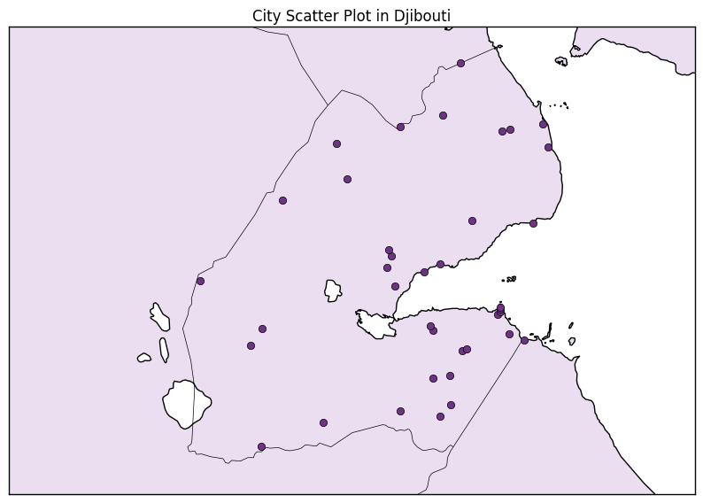

```python
plt.rcParams['figure.figsize'] = (10, 10)
m = Basemap(projection = 'merc',
            lat_0 = 11.7,
            lon_0 = 42.8,
            llcrnrlat=10.8, #lower left corner latitude
            urcrnrlat=12.8, #upper right corner latitude
            llcrnrlon=41, #lower left corner longitude
            urcrnrlon=44, #upper right corner longitude
            resolution='h',
            area_thresh = 0.1)

m.drawcoastlines()
m.drawcountries()
m.fillcontinents(color = '#EBDEF0')
m.drawmapboundary()

lats = list(df['lat'])
lons = list(df['lon'])

x, y = m(lons,lats)
m.plot(x, y, 'o', color = '#6C3483', markersize=6)
plt.title('City Scatter Plot in Djibouti')
plt.show()
```

## c)

The code is from http://www.gurobi.com/documentation/7.5/examples/tsp_py.html

```python
def distance(df, start, end):
    return df.iloc[start, end]


def subtour_eliminate(model, where):
    if where == GRB.callback.MIPSOL:
        selected = []
    # make a list of edges selected in the solution
        for start in range(n):
            sol = model.cbGetSolution([model._vars[start,end] for end in range(n)])
            selected += [(start,end) for end in range(n) if sol[end] > 0.5]
    # find the shortest cycle in the selected edge list
        tour = subtour(selected)
        if len(tour) < n:
    # add a subtour elimination constraint
            expr = 0
            for start in range(len(tour)):
                for end in range(start+1, len(tour)):
                    expr += model._vars[tour[start], tour[end]]
            model.cbLazy(expr <= len(tour)-1)

def subtour(edges):
    visited = [False]*n
    cycles = []
    lengths = []
    selected = [[] for i in range(n)]
    for x,y in edges:
        selected[x].append(y)
    while True:
        current = visited.index(False)
        thiscycle = [current]
        while True:
            visited[current] = True
            neighbors = [x for x in selected[current] if not visited[x]]
            if len(neighbors) == 0:
                break
            current = neighbors[0]
            thiscycle.append(current)
        cycles.append(thiscycle)
        lengths.append(len(thiscycle))
        if sum(lengths) == n:
            break
    return (cycles[lengths.index(min(lengths))])
```

```python
m = Model()
n = len(dis_df)
vars = {}
for start in range(n):
    for end in range(start+1):
        vars[start, end] = m.addVar(obj = distance(dis_df, start, end), vtype = GRB.BINARY, name ='e'+str(start)+'_'+str(end))
        vars[end, start] = vars[start, end]
    m.update()


for start in range(n):
    m.addConstr(quicksum(vars[start, end] for end in range(n)) == 2)
    vars[start, start].ub = 0
    m.update()

m._vars = vars
m.params.LazyConstraints = 1
m.optimize(subtour_eliminate)

solution = m.getAttr('x', vars)
selected = [(start,end) for start in range(n) for end in range(n) if solution[start,end] > 0.5]

assert len(subtour(selected)) == n
```

```
Changed value of parameter LazyConstraints to 1
   Prev: 0  Min: 0  Max: 1  Default: 0
Optimize a model with 38 rows, 741 columns and 1444 nonzeros
Variable types: 0 continuous, 741 integer (741 binary)
Coefficient statistics:
  Matrix range     [1e+00, 1e+00]
  Objective range  [6e-01, 2e+02]
  Bounds range     [1e+00, 1e+00]
  RHS range        [2e+00, 2e+00]
Found heuristic solution: objective 3385.64
Presolve removed 0 rows and 38 columns
Presolve time: 0.00s
Presolved: 38 rows, 703 columns, 1406 nonzeros
Variable types: 0 continuous, 703 integer (703 binary)

Root relaxation: objective 6.995768e+02, 49 iterations, 0.00 seconds

    Nodes    |    Current Node    |     Objective Bounds      |     Work
 Expl Unexpl |  Obj  Depth IntInf | Incumbent    BestBd   Gap | It/Node Time

     0     0  699.57682    0   10 3385.64089  699.57682  79.3%     -    0s
H    0     0                     855.2358692  699.57682  18.2%     -    0s
H    0     0                     851.9775217  699.57682  17.9%     -    0s
*    0     0               0     731.9985713  731.99857  0.00%     -    0s

Cutting planes:
  Zero half: 2
  Lazy constraints: 8

Explored 0 nodes (70 simplex iterations) in 0.07 seconds
Thread count was 4 (of 4 available processors)

Solution count 4: 731.999 851.978 855.236 3385.64
Pool objective bound 731.999

Optimal solution found (tolerance 1.00e-04)
Best objective 7.319985712548e+02, best bound 7.319985712548e+02, gap 0.0000%
```

```python
print(selected)
```

[output not shown]

## d)

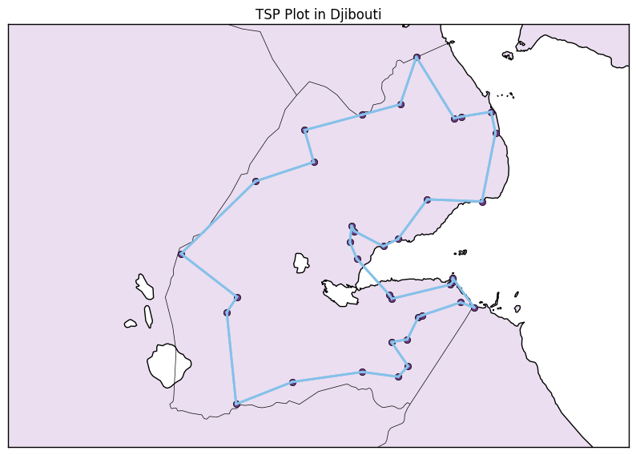

```python
plt.rcParams['figure.figsize'] = (10, 10)
m = Basemap(projection = 'merc',
            lat_0 = 11.7,
            lon_0 = 42.8,
            llcrnrlat=10.8, #lower left corner latitude
            urcrnrlat=12.8, #upper right corner latitude
            llcrnrlon=41, #lower left corner longitude
            urcrnrlon=44, #upper right corner longitude
            resolution='h',
            area_thresh = 0.1)

m.drawcoastlines()
m.drawcountries()
m.fillcontinents(color = '#EBDEF0')
m.drawmapboundary()

lats = list(df['lat'])
lons = list(df['lon'])

x, y = m(lons,lats)
m.plot(x, y, 'bo', color = '#6C3483', markersize=6)
#m.scatter(x, y, 15, marker='o', color='red')

for i in range(len(selected)):
    node_from = selected[i][0]
    node_from_lat = df.iloc[node_from][0]
    node_from_lon = df.iloc[node_from][1]

    node_to = selected[i][1]
    node_to_lat = df.iloc[node_to][0]
    node_to_lon = df.iloc[node_to][1]

    m.drawgreatcircle(node_from_lon,
                      node_from_lat,
                      node_to_lon,
                      node_to_lat,
                      linewidth=2,
                      color='#85C1E9')
plt.title('TSP Plot in Djibouti')
plt.show()
```

## Question 3

##### Kruskal's Algorithm for Min/Max Spanning Tree

```python
class Graph(object):
    def __init__(self):
        self.edges = dict() # empty dict of edge weights
        self.vertices = set() # emtpy set of vertices

    def add_edge(self, vertex1, vertex2, weight):
        self.edges[(vertex1, vertex2)] = weight
        self.vertices.add(vertex1)
        self.vertices.add(vertex2)

    def add_vertex(self, vertex):
        self.vertices.add(vertex)

    def print_edges(self):
        for k,v in self.edges.items():
            print(k, v)

    def print_vertices(self):
        for v in self.vertices:
            print(v)

    def get_edges(self):
        return self.edges

    def get_vertices(self):
        return self.vertices

    def sort_by_weight(self):
        sorted_edges = []
        for all_edges in sorted(self.edges, key = self.edges.get):
            sorted_edges.append([all_edges, self.edges[all_edges]])
        return sorted_edges
```

```python
parent = dict()
rank = dict()

def print_parent():
    for k,v in parent.items():
        print(k, v)

def print_rank():
    for k, v in rank.items():
        print(k, v)

def makeset(vertice): # constant time
    parent[vertice] = vertice
    rank[vertice] = 0

# Returns parent of the vertice to be found
def find(vertice):
    if parent[vertice] != vertice:
        parent[vertice] = find(parent[vertice])
    return parent[vertice]

def union(x, y):
    ''' make root of shorter tree point to root of taller tree
    use rank of vertices to determine height of tree'''
    root_x = find(x)
    root_y = find(y)
    if root_x == root_y:
        return
    if root_x != root_y:
        if rank[root_x] > rank[root_y]:
            parent[root_y] = root_x
        else:
            parent[root_x] = root_y
        if rank[root_x] == rank[root_y]:
            rank[root_y] += 1


def kruskal(graph):
    u = graph.get_vertices()
    for vertex in u:
        makeset(vertex)

    # Minimum Spanning Tree
    X_edges = set()
    sorted_weights = graph.sort_by_weight() # O(log m)
    for edge_weight in sorted_weights: # O(m)
        node1, node2 = edge_weight[0]
        weight = edge_weight[1]
        if find(node1) != find(node2):
            X_edges.add(((node1, node2), weight))
            union(node1, node2) # O()

    return X_edges
```

```python
g = Graph()

g.add_edge('A', 'B', 8)
g.add_edge('A', 'C', 10)
g.add_edge('B', 'D', 14)
g.add_edge('C', 'D', 6)
g.add_edge('C', 'E', 12)
g.add_edge('D', 'E', 16)
g.add_edge('E', 'F', 6)

print(g.sort_by_weight())
```

```
[[('C', 'D'), 6], [('E', 'F'), 6], [('A', 'B'), 8], [('A', 'C'), 10], [('C', 'E'), 12], [('B', 'D'), 14], [('D', 'E'), 16]]
```

```python
mst = kruskal(g)
print(mst)
```

```
{(('A', 'B'), 8), (('E', 'F'), 6), (('C', 'D'), 6), (('A', 'C'), 10), (('C', 'E'), 12)}
```

The greedy approach to finding a minimum or maximum spanning tree in a graph with n nodes and m edges follows these steps:

1. Order all edges by weight (increasing weight for minimum spanning tree, decreasing weight for maximum spanning tree).
2. For each ordered edge, add it to the tree as long as it does not create a cycle.
3. Continue until all edges are processed.

Sorting the edges in order of weight takes $O(m log m)$ time. Next, the main loop of the algorithm iterates until all the edges have been processed, which takes $O (m)$ time. Since all other operations run inside this loop, the algorithm runs in finite time, and ends onces all the edges have been processed.

Inside this main loop, there are two operations, $find$ and $union$, to check whether an edge will create a cycle if it is added to the spanning tree.

To determine if adding the next edge will create a cycle, the algorithm checks whether the edge links two parts of a cut. By definition, a cut is any partition between two sets of vertices, and adding an edge (lightest or heaviest, depending on whether the algorithm is finding a maximum or minimum spanning tree) from the list of ordered edges between any cut is guaranteed not to create a cycle if there are no edges already existing between the two partitions of the cut. Initially, each vertex of the graph is assigned to a set, which takes $O(1)$ time, and each time a new edge is processed, its endpoints are checked to see whether they belong to the same set or different sets. This operation, called $find$, takes $O (n)$ time. The new edge can be added to the spanning tree if each of its nodes are part of different partitions of the cut. If they are part of the same partition, they are already part of a tree and their addition would create a cycle.

If both endpoints of the new edge are in different partitions, the edge links two parts of a cut, and the new edge is added to the spanning tree's edges. Furthermore, the edge's endpoints are linked through a $union$ operation. A union stores each set of nodes as a tree structure, with each additional node being assigned as the child of an existing node in that set. When two sets of nodes are merged by a union, the smallest tree's root node points to the root of the largest tree. This operation takes $O (n)$ time.